# STAT364 Data Science Diagnostics and Problems with Predictors Homework 03

Kira Novitchkova-Burbank

# Chapter 6 Problem 1:

### Using the sat dataset, fit a model with the total SAT score as the response and expend, salary, ratio and takers as predictors. Perform regression diagnostics on this model to answer the following questions. Display any plots that are relevant. Do not provide any plots about which you have nothing to say. Suggest possible improvements or corrections to the model where appropriate.

### (a) Check the constant variance assumption for the errors.

Your code:

```r
library(faraway)
data(sat, package = "faraway")
summary(sat)
```

```
##      expend          ratio           salary          takers
##  Min.   :3.656   Min.   :13.80   Min.   :25.99   Min.   : 4.00
##  1st Qu.:4.882   1st Qu.:15.22   1st Qu.:30.98   1st Qu.: 9.00
##  Median :5.768   Median :16.60   Median :33.29   Median :28.00
##  Mean   :5.905   Mean   :16.86   Mean   :34.83   Mean   :35.24
##  3rd Qu.:6.434   3rd Qu.:17.57   3rd Qu.:38.55   3rd Qu.:63.00
##  Max.   :9.774   Max.   :24.30   Max.   :50.05   Max.   :81.00
##      verbal           math           total
##  Min.   :401.0   Min.   :443.0   Min.   : 844.0
##  1st Qu.:427.2   1st Qu.:474.8   1st Qu.: 897.2
##  Median :448.0   Median :497.5   Median : 945.5
##  Mean   :457.1   Mean   :508.8   Mean   : 965.9
##  3rd Qu.:490.2   3rd Qu.:539.5   3rd Qu.:1032.0
##  Max.   :516.0   Max.   :592.0   Max.   :1107.0
```

```r
lmod <- lm(total ~ expend + salary + ratio + takers, data = sat)
lmod
```

```
##
## Call:
## lm(formula = total ~ expend + salary + ratio + takers, data = sat)
##
## Coefficients:
## (Intercept)       expend       salary        ratio       takers
##    1045.972        4.463        1.638       -3.624       -2.904
```

**Making a plot with Fitted on the x-axis and Residuals on the y-axis:**

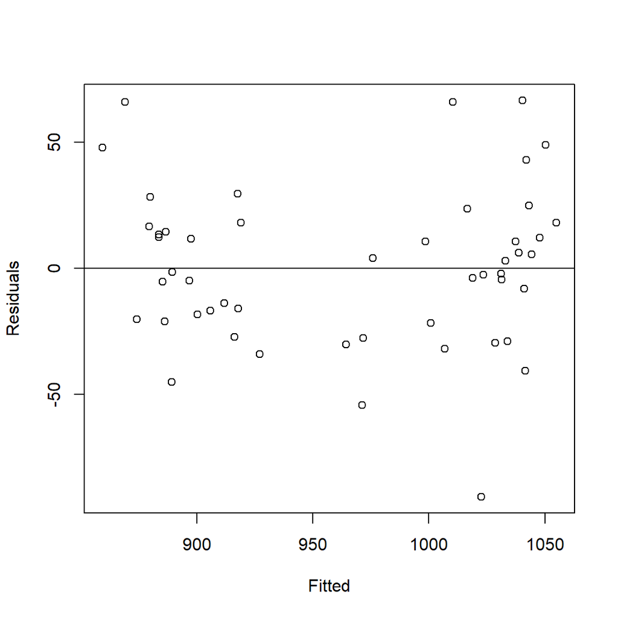

```r
plot(fitted(lmod),residuals(lmod),xlab="Fitted",ylab="Residuals")
abline(h=0)
```

**Your answer:** By looking at this plot, it seems like there is constant variance because there is no pattern in the data points.

**Put your answer, explanation, findings here**

### (b) Check the normality assumption.

Your code:

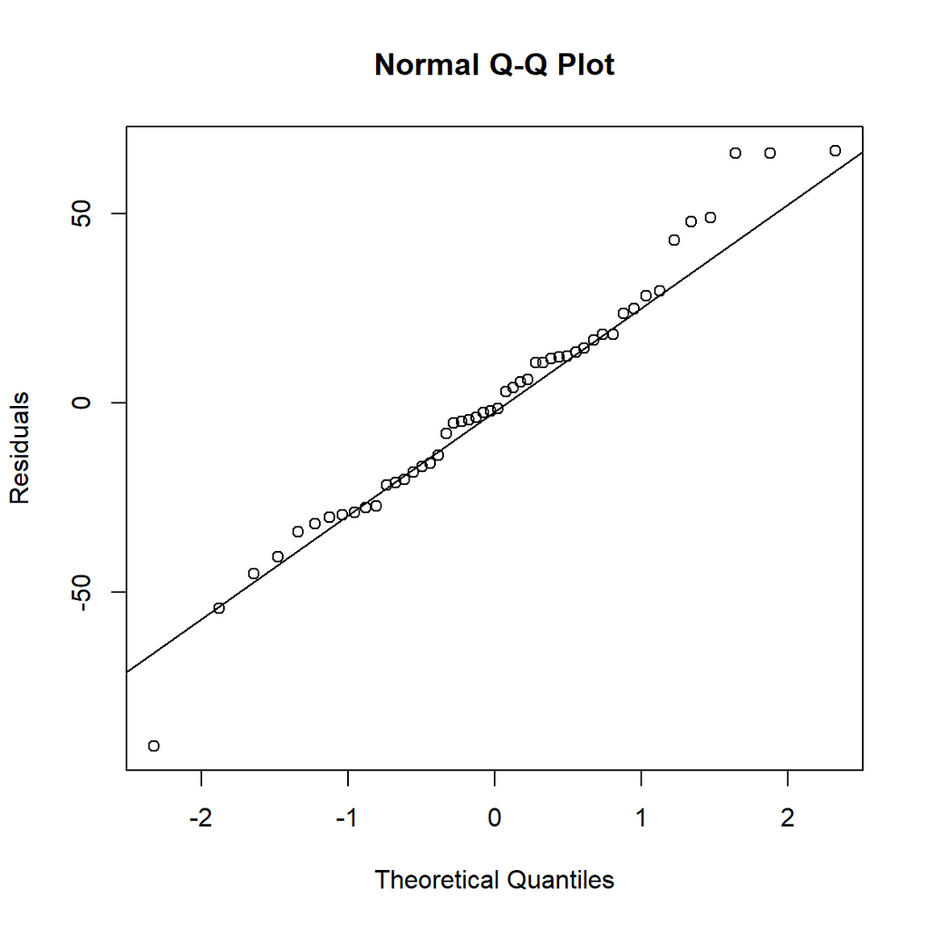

```r
#Q-Q Plot
qqnorm(residuals(lmod), ylab="Residuals", main="Normal Q-Q Plot")
qqline(residuals(lmod))
```

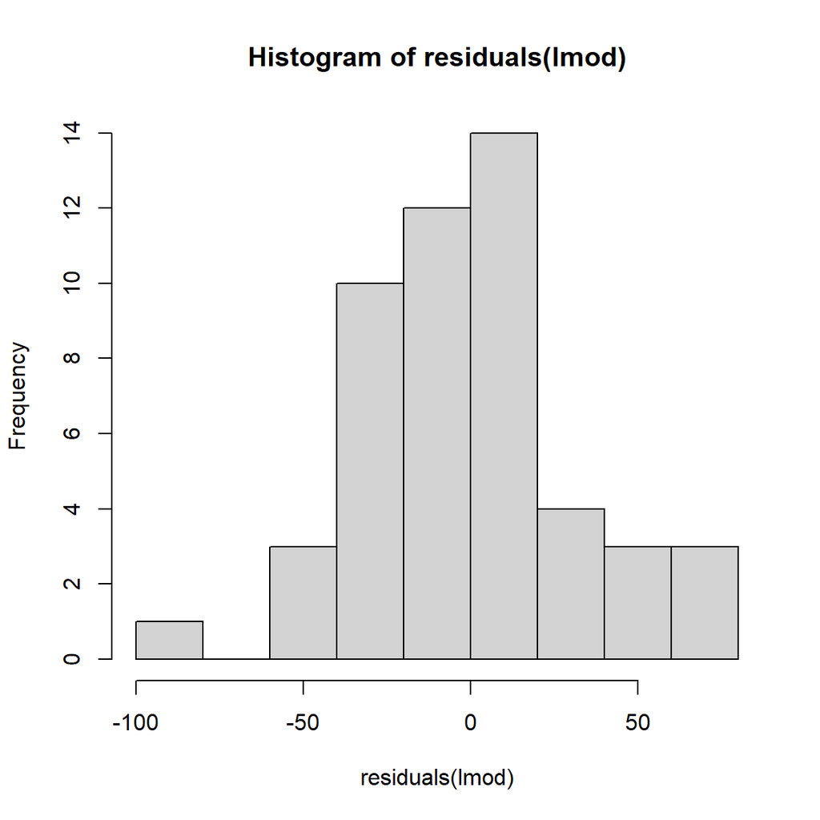

```r
#histogram
hist(residuals(lmod))
```

**Your answer:** The Q-Q plot shows that the residuals follow a normal distribution because of where the data points are. Also, it seems like the median is 0. The histogram shows roughly a normal distribution because the bell-shaped curve is roughly in the middle. Although, the histogram also shows that it might be just slightly skewed because of the way the curve is.

**Put your answer, explanation, findings here**

### (c) Check for large leverage points.

```r
hat_val = hatvalues(lmod)
head(hat_val)
```

```
##    Alabama     Alaska    Arizona   Arkansas California   Colorado
## 0.09537668 0.18030612 0.04931612 0.05382878 0.28211791 0.03014533
```

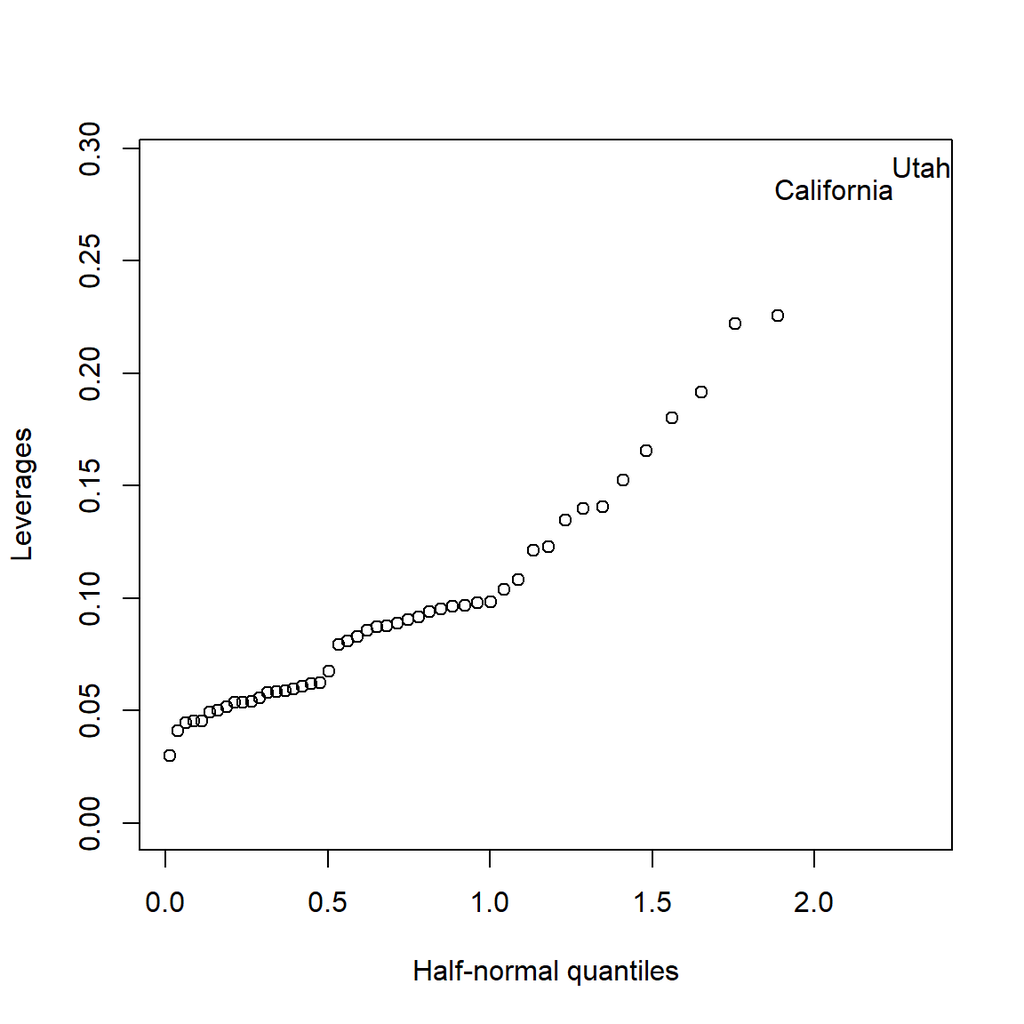

```r
library(faraway)
states = row.names(sat)
halfnorm(hat_val, labs=states, ylab="Leverages")
```

**Your answer:** Since Utah and California are labeled, that means that they are large leverage points.

**Put your answer, explanation, findings here**

### (d) Check for outliers.

```r
r_stud = rstudent(lmod)
r_stud
```

```
##        Alabama         Alaska        Arizona       Arkansas     California
##    -0.06574555    -1.02091600    -0.86394293    -0.90546917    -0.56764583
##       Colorado    Connecticut       Delaware        Florida        Georgia
##     0.12375609     0.97811087     0.41584816    -0.89619150    -0.64380944
##         Hawaii          Idaho       Illinois        Indiana           Iowa
##    -0.52185887    -0.68138366     0.34240342    -0.57108388     1.56037417
##         Kansas       Kentucky      Louisiana          Maine       Maryland
##     0.38967283    -0.92044224    -0.08013841     0.53951189     0.36099300
##  Massachusetts       Michigan      Minnesota    Mississippi       Missouri
##     1.55127336    -0.26522896     1.36779678     0.09173934     0.19418490
##        Montana       Nebraska         Nevada  New Hampshire     New Jersey
##     0.34070604     0.17614652    -1.73200396     2.19000605    -0.47250752
##     New Mexico       New York North Carolina   North Dakota           Ohio
##    -0.11823952    -0.16415440    -0.67193751     2.21368580    -0.99430251
##       Oklahoma         Oregon   Pennsylvania   Rhode Island South Carolina
##    -0.13785064     0.94590973    -0.17154457    -0.04457306    -1.46883156
##   South Dakota      Tennessee          Texas           Utah        Vermont
##     0.79638212     0.75084252    -1.07088136     2.52958734     0.45748671
##       Virginia     Washington  West Virginia      Wisconsin        Wyoming
##     0.40448538     0.58126580    -3.12442832     0.57665563    -1.31188995
```

```r
r_stud[which.max(abs(r_stud))]
```

```
## West Virginia
##     -3.124428
```

**Your answer:** Don’t want this point to be too large in absolute value. You want this value to be close to 0 for it to not be an outlier. Although, abs(-3.124428) is obviously not close to 0, so it is an outlier.

**Put your answer, explanation, findings here**

## (e) Check for influential points.

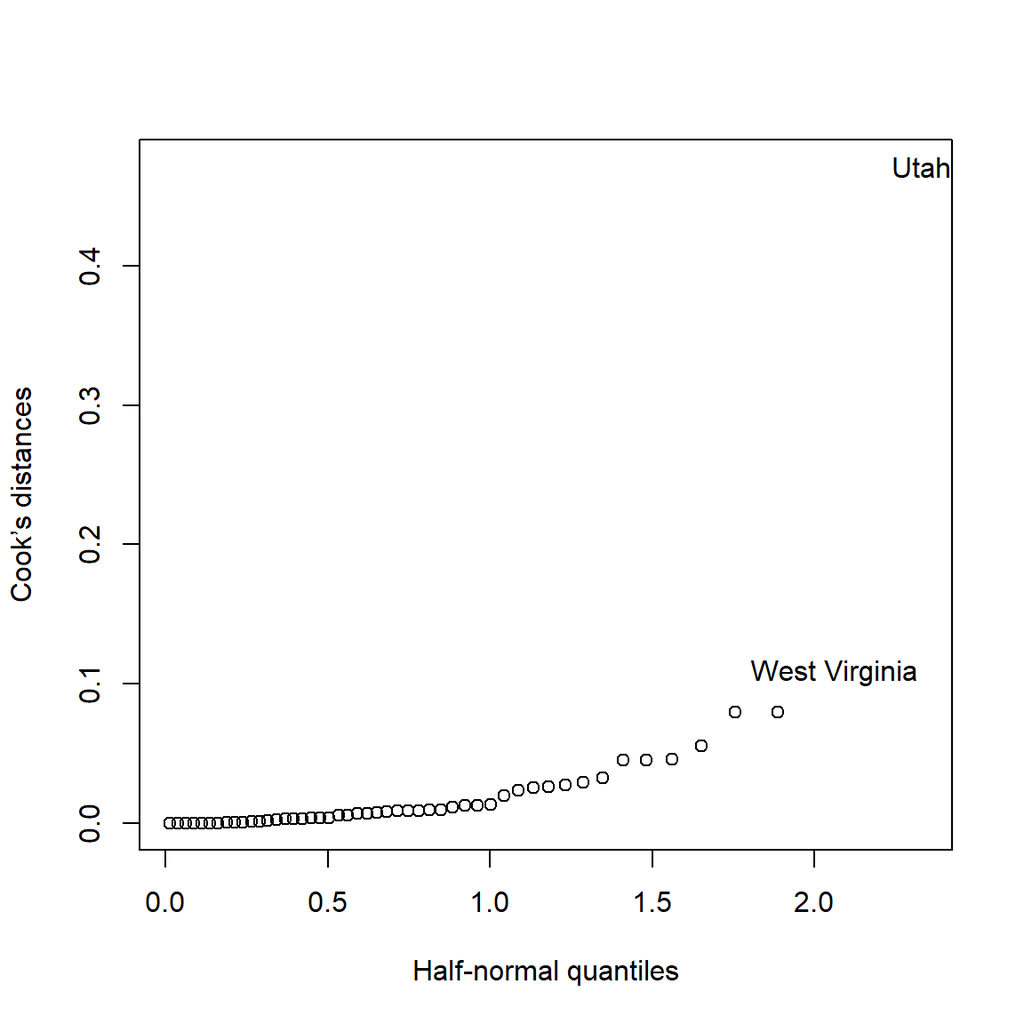

```r
cook_distance = cooks.distance(lmod)
halfnorm(cook_distance, labs=states, ylab="Cook’s distances")
```

**Your answer:** Utah and West Virginia are the influential points because they are labeled.

**Put your answer, explanation, findings here**

## (f) Check the structure of the relationship between the predictors and the response.

Your code:

```r
library(faraway)
library(tidyverse)
lmod <- lm(total ~ expend + salary + ratio + takers, data = sat)
lmod
```

```
##
## Call:
## lm(formula = total ~ expend + salary + ratio + takers, data = sat)
##
## Coefficients:
## (Intercept)       expend       salary        ratio       takers
##    1045.972        4.463        1.638       -3.624       -2.904
```

```r
#install.packages("car")
library(car)
```

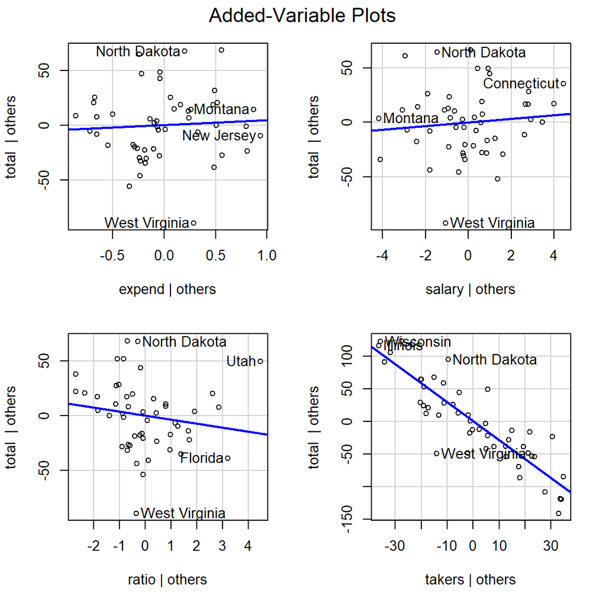

```r
library(carData)
avPlots(lmod)
```

**Your answer:**

These avplot’s show that: There is a slight positive linear relationship between the predictor expend and the response total. There is a slight positive linear relationship between the predictor salary and the response total. There is a negative linear relationship between the predictor ratio and the response total. There is a negative linear relationship between the predictor takers and the response total.

**Put your answer, explanation, findings here**

# Chapter 6 Problem 2:

### Using the teengamb dataset, fit a model with gamble as the response and the other variables as predictors. Answer the questions posed in the previous question.

### (a) Check the constant variance assumption for the errors.

Your code:

```r
library(faraway)
data(teengamb, package = "faraway")
summary(teengamb)
```

```
##       sex             status          income           verbal
##  Min.   :0.0000   Min.   :18.00   Min.   : 0.600   Min.   : 1.00
##  1st Qu.:0.0000   1st Qu.:28.00   1st Qu.: 2.000   1st Qu.: 6.00
##  Median :0.0000   Median :43.00   Median : 3.250   Median : 7.00
##  Mean   :0.4043   Mean   :45.23   Mean   : 4.642   Mean   : 6.66
##  3rd Qu.:1.0000   3rd Qu.:61.50   3rd Qu.: 6.210   3rd Qu.: 8.00
##  Max.   :1.0000   Max.   :75.00   Max.   :15.000   Max.   :10.00
##      gamble
##  Min.   :  0.0
##  1st Qu.:  1.1
##  Median :  6.0
##  Mean   : 19.3
##  3rd Qu.: 19.4
##  Max.   :156.0
```

```r
lmod <- lm(gamble ~ sex + status + income + verbal, data = teengamb)
lmod
```

```
##
## Call:
## lm(formula = gamble ~ sex + status + income + verbal, data = teengamb)
##
## Coefficients:
## (Intercept)          sex       status       income       verbal
##    22.55565    -22.11833      0.05223      4.96198     -2.95949
```

Making a plot with Fitted on the x-axis and Residuals on the y-axis

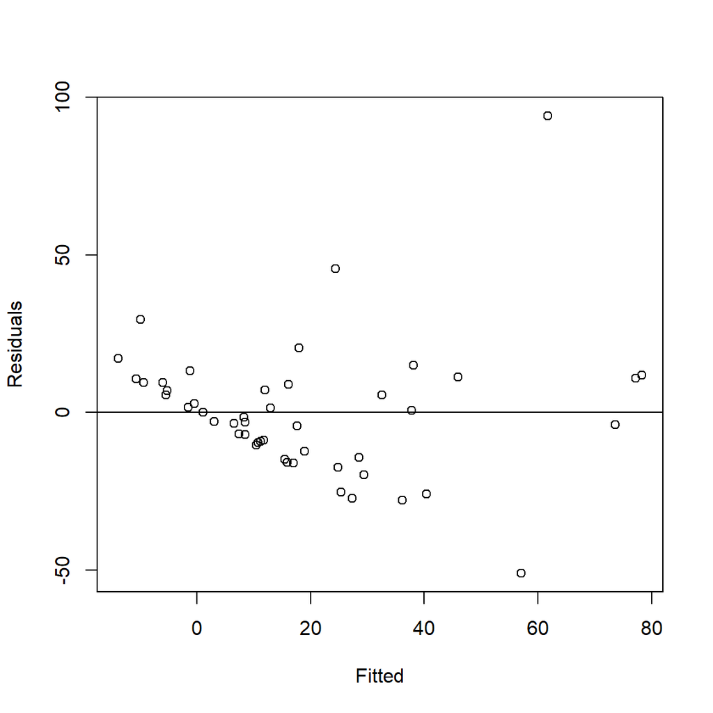

```r
plot(fitted(lmod), residuals(lmod), xlab="Fitted", ylab="Residuals")
abline(h=0)
```

**Your answer:** By looking at this plot, it seems like there is non-constant variance because it somewhat looks linear at the lower fitted values then kind of like a megaphone then it looks like there are data points in random places.

**Put your answer, explanation, findings here**

### (b) Check the normality assumption.

Your code:

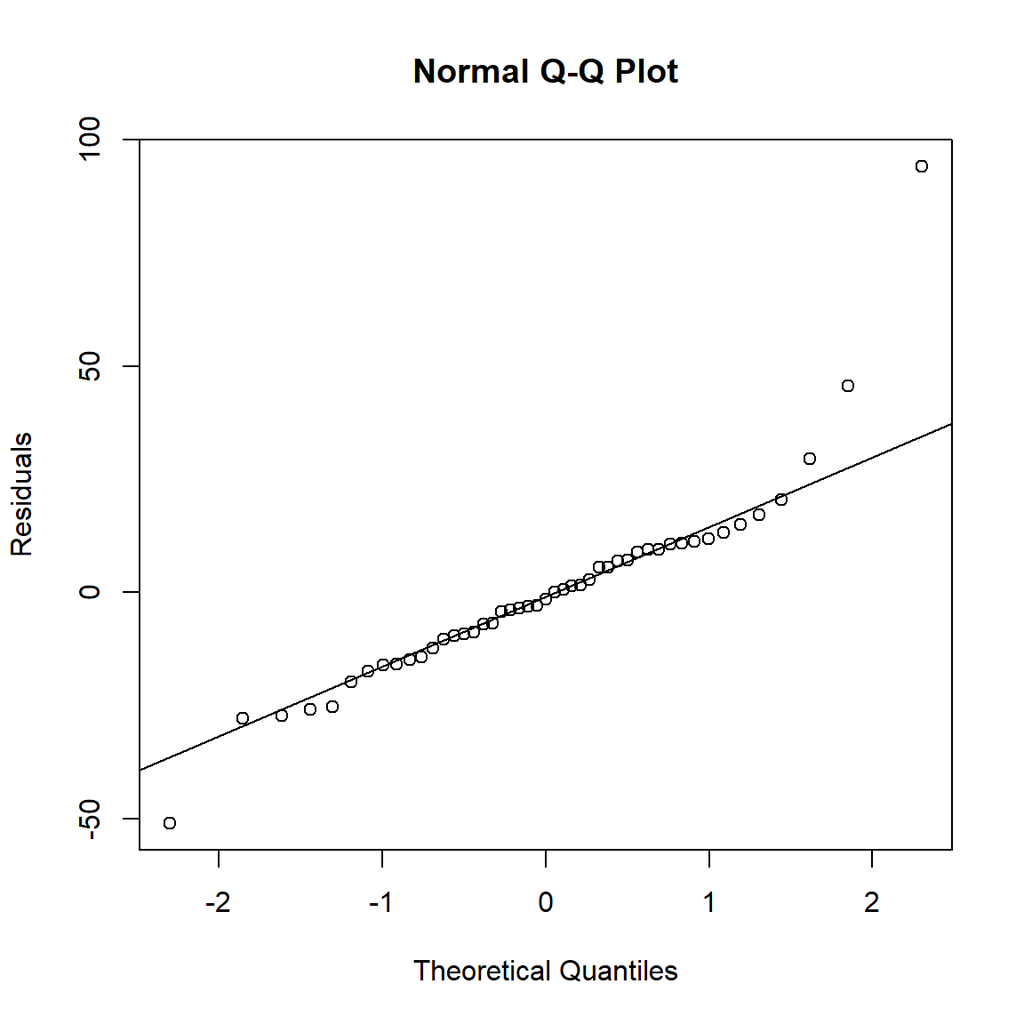

```r
#Q-Q Plot
qqnorm(residuals(lmod), ylab="Residuals", main="Normal Q-Q Plot")
qqline(residuals(lmod))
```

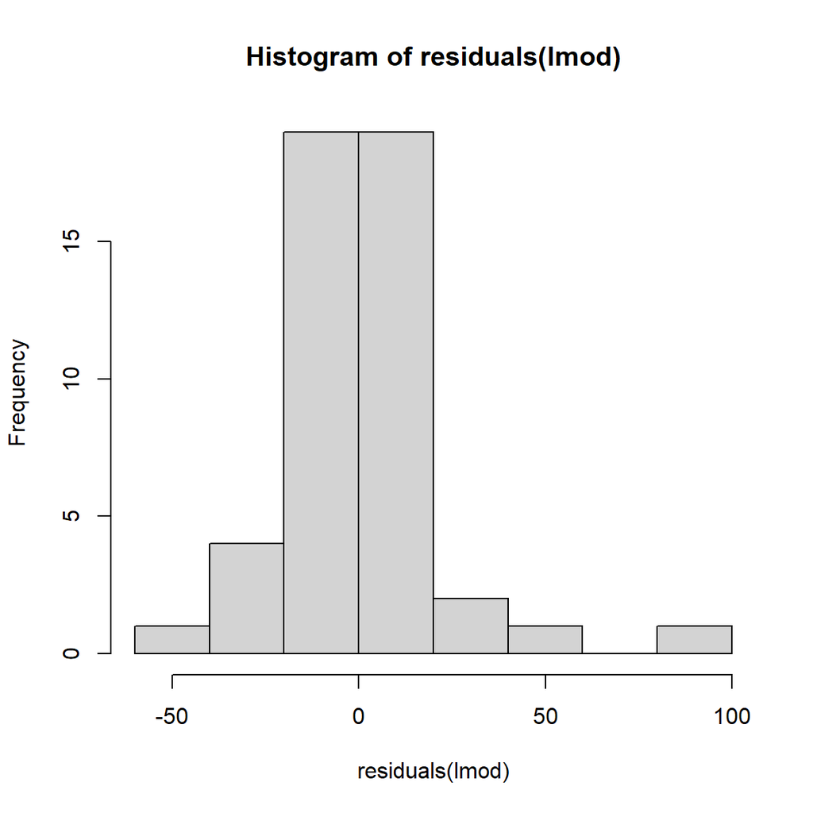

```r
#histogram
hist(residuals(lmod))
```

**Your answer:** Check if this is right: The Q-Q plot shows that the residuals do not really follow normal distribution because of where the data points are. It seems like they follow the heavy-tail distribution. The histogram shows that it is a roughly normal distribution with potential outliers because of the little bar by the 100 on the residuals(lmod) axis.

**Put your answer, explanation, findings here**

### (c) Check for large leverage points.

```r
hat_val = hatvalues(lmod)
head(hat_val)
```

```
##          1          2          3          4          5          6
## 0.07988226 0.10851291 0.06347643 0.10273955 0.13866946 0.16378563
```

```r
library(faraway)
head(teengamb)
```

```
##   sex status income verbal gamble
## 1   1     51   2.00      8    0.0
## 2   1     28   2.50      8    0.0
## 3   1     37   2.00      6    0.0
## 4   1     28   7.00      4    7.3
## 5   1     65   2.00      8   19.6
## 6   1     61   3.47      6    0.1
```

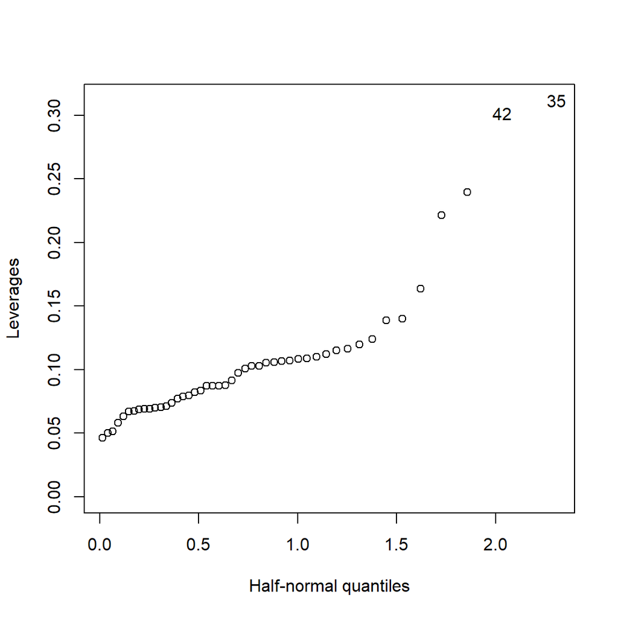

```r
values = row.names(teengamb)
halfnorm(hat_val, labs=values, ylab="Leverages")
```

**Your answer:** Since values 42 and 35 are labeled, that means that they are large leverage points.

**Put your answer, explanation, findings here**

### (d) Check for outliers.

```r
r_stud = rstudent(lmod)
r_stud
```

```
##            1            2            3            4            5            6
##  0.484870822  0.433163892  0.245991849 -0.810686033  1.418582717 -0.142158866
##            7            8            9           10           11           12
## -0.317374225 -0.558091790  0.309727471 -0.477911450  0.073183900 -0.139821862
##           13           14           15           16           17           18
##  0.005399136  0.432273837  0.127853362  0.788830437 -1.207094189 -1.317398465
##           19           20           21           22           23           24
##  0.595780320 -0.731951082 -0.719525173 -0.444490542 -1.252647338  6.016116345
##           25           26           27           28           29           30
##  0.032148197 -0.424594254 -1.212679116 -0.404491482 -0.312262299 -0.894246583
##           31           32           33           34           35           36
##  0.545192798  0.697965557  0.582020953 -0.165636151 -0.761255710  2.144825887
##           37           38           39           40           41           42
##  0.943967209  0.517035886 -2.506089824  0.404973252 -0.067239855 -0.199979504
##           43           44           45           46           47
## -0.199861425 -0.675872750  0.245946047  0.064230138  0.325550756
```

```r
r_stud[which.max(abs(r_stud))]
```

```
##       24
## 6.016116
```

**Your answer:** Don’t want this point to be too large in absolute value. You want this value to be close to 0 for it to not be an outlier. Although, 6.016116 is obviously not close to 0, so it is an outlier.

**Put your answer, explanation, findings here**

## (e) Check for influential points.

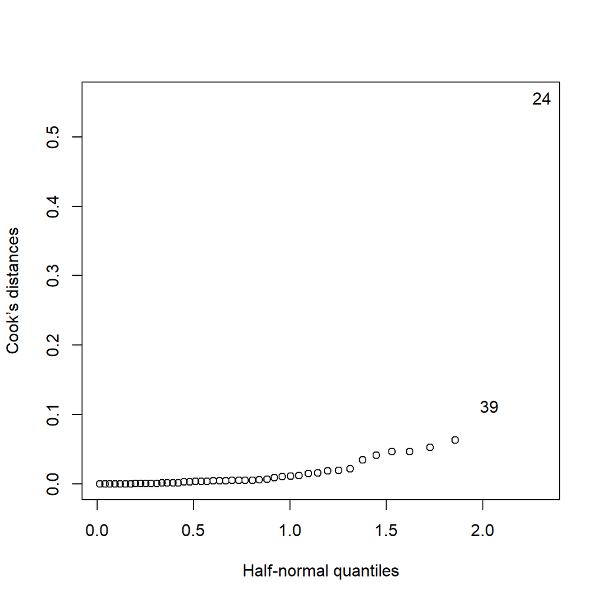

```r
cook_distance = cooks.distance(lmod)
halfnorm(cook_distance, labs=values, ylab="Cook’s distances")
```

**Your answer:** Values 39 and 24 are the influential points because they are labeled.

**Put your answer, explanation, findings here**

## (f) Check the structure of the relationship between the predictors and the response.

Your code:

```r
library(faraway)
library(tidyverse)

lmod <- lm(gamble ~ sex + status + income + verbal, data = teengamb)
lmod
```

```
##
## Call:
## lm(formula = gamble ~ sex + status + income + verbal, data = teengamb)
##
## Coefficients:
## (Intercept)          sex       status       income       verbal
##    22.55565    -22.11833      0.05223      4.96198     -2.95949
```

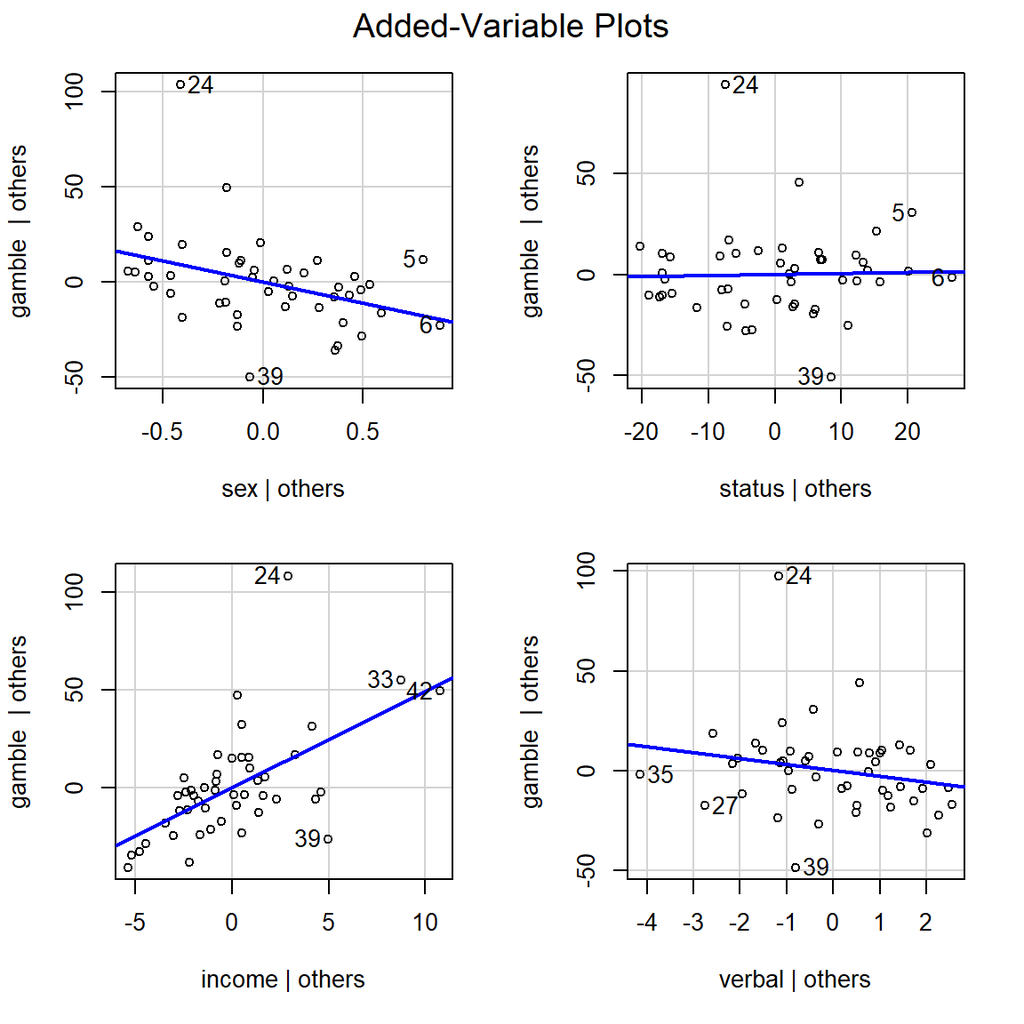

```r
library(car)
library(carData)

avPlots(lmod)
```

**Your answer:**

These avplot’s show that: There is a negative linear relationship between the predictor sex and the response gamble. There seems to be a very slight positive linear relationship between the predictor status and the response gamble. There is a positive linear relationship between the predictor income and the response gamble. There is a negative linear relationship between the predictor verbal and the response gamble.

**Put your answer, explanation, findings here**

# Chapter 7 Problem 3:

### Using the divusa data: (a) Fit a regression model with divorce as the response and unemployed, femlab, marriage, birth and military as predictors. Compute the condition numbers and interpret their meanings.

Your code:

```r
data(divusa, package = "faraway")
summary(divusa)
```

```
##       year         divorce        unemployed         femlab
##  Min.   :1920   Min.   : 6.10   Min.   : 1.200   Min.   :22.70
##  1st Qu.:1939   1st Qu.: 8.70   1st Qu.: 4.200   1st Qu.:27.47
##  Median :1958   Median :10.60   Median : 5.600   Median :37.10
##  Mean   :1958   Mean   :13.27   Mean   : 7.173   Mean   :38.58
##  3rd Qu.:1977   3rd Qu.:20.30   3rd Qu.: 7.500   3rd Qu.:47.80
##  Max.   :1996   Max.   :22.80   Max.   :24.900   Max.   :59.30
##     marriage          birth           military
##  Min.   : 49.70   Min.   : 65.30   Min.   : 1.940
##  1st Qu.: 61.90   1st Qu.: 68.90   1st Qu.: 3.469
##  Median : 74.10   Median : 85.90   Median : 9.102
##  Mean   : 72.97   Mean   : 88.89   Mean   :12.365
##  3rd Qu.: 80.00   3rd Qu.:107.30   3rd Qu.:14.266
##  Max.   :118.10   Max.   :122.90   Max.   :86.641
```

```r
lmod <- lm(divorce ~ unemployed + femlab + marriage + birth + military, data = divusa)
lmod
```

```
##
## Call:
## lm(formula = divorce ~ unemployed + femlab + marriage + birth +
##     military, data = divusa)
##
## Coefficients:
## (Intercept)   unemployed       femlab     marriage        birth     military
##     2.48784     -0.11125      0.38365      0.11867     -0.12996     -0.02673
```

```r
summary(lmod)
```

```
##
## Call:
## lm(formula = divorce ~ unemployed + femlab + marriage + birth +
##     military, data = divusa)
##
## Residuals:
##     Min      1Q  Median      3Q     Max
## -3.8611 -0.8916 -0.0496  0.8650  3.8300
##
## Coefficients:
##             Estimate Std. Error t value Pr(>|t|)
## (Intercept)  2.48784    3.39378   0.733   0.4659
## unemployed  -0.11125    0.05592  -1.989   0.0505 .
## femlab       0.38365    0.03059  12.543  < 2e-16 ***
## marriage     0.11867    0.02441   4.861 6.77e-06 ***
## birth       -0.12996    0.01560  -8.333 4.03e-12 ***
## military    -0.02673    0.01425  -1.876   0.0647 .
## ---
## Signif. codes:  0 '***' 0.001 '**' 0.01 '*' 0.05 '.' 0.1 ' ' 1
##
## Residual standard error: 1.65 on 71 degrees of freedom
## Multiple R-squared:  0.9208, Adjusted R-squared:  0.9152
## F-statistic: 165.1 on 5 and 71 DF,  p-value: < 2.2e-16
```

Doing eigenvalue test:

```r
x <- model.matrix(lmod)[,-1]
e <- eigen(t(x) %*% x)
e$val
```

```
## [1] 1174600.548   21261.741   16133.842    6206.181    1856.894
```

These are the condition numbers also known as ratios:

```r
sqrt(e$val[1]/e$val)
```

```
## [1]  1.000000  7.432684  8.532498 13.757290 25.150782
```

**Your answer:** If the eigenvalues and the condition numbers (aka ratios) are between 0 and 1 then there are no collinearity issues. If the eigenvalues are not in between 0 and 1 and the condition numbers are really big then that means that there could be collinearity issues. In this case, both the eigenvalues and the condition numbers are really big, so there could be collinearity issues.

**Put your answer, explanation, findings here**

### (b) For the same model, compute the VIFs. Is there evidence that collinearity causes some predictors not to be significant? Explain.

```r
library(car)
library(carData)

#variance inflation factor quantifies the collinearity of each predictor
#if the model preforms bad then it inflates the variance which are the values in the output below
#so don't want large vif

vif(lmod)
```

```
## unemployed     femlab   marriage      birth   military
##   2.252888   3.613276   2.864864   2.585485   1.249596
```

**Your answer:** If vif is really huge, then will have collinearity issues. Especially if there is a scaling problem like if there are some values that are a lot bigger than the others. For no collinearity issues, looking for values around 5 or < 5 or < 10 and values that are all similar in size. So, based on this output from vif, it seems like there are no collinearity issues.

**Put your answer, explanation, findings here**

### (c) Does the removal of insignificant predictors from the model reduce the collinearity? Investigate.

```r
summary(lmod)
```

```
##
## Call:
## lm(formula = divorce ~ unemployed + femlab + marriage + birth +
##     military, data = divusa)
##
## Residuals:
##     Min      1Q  Median      3Q     Max
## -3.8611 -0.8916 -0.0496  0.8650  3.8300
##
## Coefficients:
##             Estimate Std. Error t value Pr(>|t|)
## (Intercept)  2.48784    3.39378   0.733   0.4659
## unemployed  -0.11125    0.05592  -1.989   0.0505 .
## femlab       0.38365    0.03059  12.543  < 2e-16 ***
## marriage     0.11867    0.02441   4.861 6.77e-06 ***
## birth       -0.12996    0.01560  -8.333 4.03e-12 ***
## military    -0.02673    0.01425  -1.876   0.0647 .
## ---
## Signif. codes:  0 '***' 0.001 '**' 0.01 '*' 0.05 '.' 0.1 ' ' 1
##
## Residual standard error: 1.65 on 71 degrees of freedom
## Multiple R-squared:  0.9208, Adjusted R-squared:  0.9152
## F-statistic: 165.1 on 5 and 71 DF,  p-value: < 2.2e-16
```

**Your answer:** The insignificant predictors are military and unemployed because their p-values are > 0.05. So, we remove them.

```r
lmod_partial <- lm(divorce ~ femlab + marriage + birth, data = divusa)
lmod_partial
```

```
##
## Call:
## lm(formula = divorce ~ femlab + marriage + birth, data = divusa)
##
## Coefficients:
## (Intercept)       femlab     marriage        birth
##     -1.5455       0.4134       0.1261      -0.1163
```

**Find condition numbers:**

Doing eigenvalue test:

```r
x <- model.matrix(lmod_partial)[,-1]
e <- eigen(t(x) %*% x)
e$val
```

```
## [1] 1158413.60   20972.53    6208.46
```

These are the condition numbers:

```r
sqrt(e$val[1]/e$val)
```

```
## [1]  1.000000  7.432012 13.659660
```

**Your answer:** If the eigenvalues and the condition numbers (aka ratios) are between 0 and 1 then there are no collinearity issues. If the eigenvalues are not in between 0 and 1 and the condition numbers are really big then that means that there could be collinearity issues. In this case, both the eigenvalues and the condition numbers are really big, so there could be collinearity issues.

Finding vif:

```r
library(car)
library(carData)

#variance inflation factor quantifies the collinearity of each predictor
#if the model preforms bad then it inflates the variance which are the values in the output below
#so don't want large vif

vif(lmod_partial)
```

```
##   femlab marriage    birth
## 1.893390 2.201891 2.008469
```

**Your answer:** If vif is really huge, then will have collinearity issues. Especially if there is a scaling problem like if there are some values that are a lot bigger than the others. For no collinearity issues, looking for values around 5 or < 5 or < 10 and values that are all similar in size. So, based on this output from vif, it seems like there are no collinearity issues.

The vif from the previous model showed that there wasn’t any collinearity and this one still doesn’t show any collinearity even with a smaller amount of predictors. That’s a good thing because you don’t want there to be collinearity all of a sudden. But it still didn’t really reduce the collinearity because neither model had collinearity issues. It just reduced the amount of predictors.

**Put your answer, explanation, findings here**

# Chapter 7 Problem 8:

### Use the fat data, fitting the model described in Section 4.2. (a) Compute the condition numbers and variance inflation factors. Comment on the degree of collinearity observed in the data.

```r
data(fat, package = "faraway")
summary(fat)
```

```
##      brozek           siri          density           age
##  Min.   : 0.00   Min.   : 0.00   Min.   :0.995   Min.   :22.00
##  1st Qu.:12.80   1st Qu.:12.47   1st Qu.:1.041   1st Qu.:35.75
##  Median :19.00   Median :19.20   Median :1.055   Median :43.00
##  Mean   :18.94   Mean   :19.15   Mean   :1.056   Mean   :44.88
##  3rd Qu.:24.60   3rd Qu.:25.30   3rd Qu.:1.070   3rd Qu.:54.00
##  Max.   :45.10   Max.   :47.50   Max.   :1.109   Max.   :81.00
##      weight          height          adipos           free
##  Min.   :118.5   Min.   :29.50   Min.   :18.10   Min.   :105.9
##  1st Qu.:159.0   1st Qu.:68.25   1st Qu.:23.10   1st Qu.:131.3
##  Median :176.5   Median :70.00   Median :25.05   Median :141.6
##  Mean   :178.9   Mean   :70.15   Mean   :25.44   Mean   :143.7
##  3rd Qu.:197.0   3rd Qu.:72.25   3rd Qu.:27.32   3rd Qu.:153.9
##  Max.   :363.1   Max.   :77.75   Max.   :48.90   Max.   :240.5
##       neck           chest            abdom             hip
##  Min.   :31.10   Min.   : 79.30   Min.   : 69.40   Min.   : 85.0
##  1st Qu.:36.40   1st Qu.: 94.35   1st Qu.: 84.58   1st Qu.: 95.5
##  Median :38.00   Median : 99.65   Median : 90.95   Median : 99.3
##  Mean   :37.99   Mean   :100.82   Mean   : 92.56   Mean   : 99.9
##  3rd Qu.:39.42   3rd Qu.:105.38   3rd Qu.: 99.33   3rd Qu.:103.5
##  Max.   :51.20   Max.   :136.20   Max.   :148.10   Max.   :147.7
##      thigh            knee           ankle          biceps         forearm
##  Min.   :47.20   Min.   :33.00   Min.   :19.1   Min.   :24.80   Min.   :21.00
##  1st Qu.:56.00   1st Qu.:36.98   1st Qu.:22.0   1st Qu.:30.20   1st Qu.:27.30
##  Median :59.00   Median :38.50   Median :22.8   Median :32.05   Median :28.70
##  Mean   :59.41   Mean   :38.59   Mean   :23.1   Mean   :32.27   Mean   :28.66
##  3rd Qu.:62.35   3rd Qu.:39.92   3rd Qu.:24.0   3rd Qu.:34.33   3rd Qu.:30.00
##  Max.   :87.30   Max.   :49.10   Max.   :33.9   Max.   :45.00   Max.   :34.90
##      wrist
##  Min.   :15.80
##  1st Qu.:17.60
##  Median :18.30
##  Mean   :18.23
##  3rd Qu.:18.80
##  Max.   :21.40
```

```r
lmod <- lm(brozek ~ age + weight + height + neck + chest + abdom + hip + thigh + knee + ankle + biceps + forearm + wrist, data = fat)
lmod
```

```
##
## Call:
## lm(formula = brozek ~ age + weight + height + neck + chest +
##     abdom + hip + thigh + knee + ankle + biceps + forearm + wrist,
##     data = fat)
##
## Coefficients:
## (Intercept)          age       weight       height         neck        chest
##   -15.29255      0.05679     -0.08031     -0.06460     -0.43754     -0.02360
##       abdom          hip        thigh         knee        ankle       biceps
##     0.88543     -0.19842      0.23190     -0.01168      0.16354      0.15280
##     forearm        wrist
##     0.43049     -1.47654
```

```r
summary(lmod)
```

```
##
## Call:
## lm(formula = brozek ~ age + weight + height + neck + chest +
##     abdom + hip + thigh + knee + ankle + biceps + forearm + wrist,
##     data = fat)
##
## Residuals:
##     Min      1Q  Median      3Q     Max
## -10.264  -2.572  -0.097   2.898   9.327
##
## Coefficients:
##              Estimate Std. Error t value Pr(>|t|)
## (Intercept) -15.29255   16.06992  -0.952  0.34225
## age           0.05679    0.02996   1.895  0.05929 .
## weight       -0.08031    0.04958  -1.620  0.10660
## height       -0.06460    0.08893  -0.726  0.46830
## neck         -0.43754    0.21533  -2.032  0.04327 *
## chest        -0.02360    0.09184  -0.257  0.79740
## abdom         0.88543    0.08008  11.057  < 2e-16 ***
## hip          -0.19842    0.13516  -1.468  0.14341
## thigh         0.23190    0.13372   1.734  0.08418 .
## knee         -0.01168    0.22414  -0.052  0.95850
## ankle         0.16354    0.20514   0.797  0.42614
## biceps        0.15280    0.15851   0.964  0.33605
## forearm       0.43049    0.18445   2.334  0.02044 *
## wrist        -1.47654    0.49552  -2.980  0.00318 **
## ---
## Signif. codes:  0 '***' 0.001 '**' 0.01 '*' 0.05 '.' 0.1 ' ' 1
##
## Residual standard error: 3.988 on 238 degrees of freedom
## Multiple R-squared:  0.749,  Adjusted R-squared:  0.7353
## F-statistic: 54.63 on 13 and 238 DF,  p-value: < 2.2e-16
```

Doing eigenvalue test:

```r
x <- model.matrix(lmod)[,-1]
e <- eigen(t(x) %*% x)
e$val
```

```
##  [1] 1.959256e+07 6.418499e+04 3.059739e+04 5.704341e+03 2.803947e+03
##  [6] 1.934715e+03 1.030340e+03 6.376692e+02 5.280964e+02 4.318186e+02
## [11] 3.763758e+02 2.723663e+02 6.345357e+01
```

These are the condition numbers:

```r
sqrt(e$val[1]/e$val)
```

```
##  [1]   1.00000  17.47144  25.30482  58.60610  83.59121 100.63222 137.89717
##  [8] 175.28623 192.61449 213.00748 228.15747 268.20620 555.67072
```

**Your answer:** If the eigenvalues and the condition numbers (aka ratios) are between 0 and 1 then there are no collinearity issues. If the eigenvalues are not in between 0 and 1 and the condition numbers are really big then that means that there could be collinearity issues. In this case, both the eigenvalues and the condition numbers are really big, so there could be collinearity issues.

Finding VIF:

```r
library(car)
library(carData)

vif(lmod)
```

```
##       age    weight    height      neck     chest     abdom       hip     thigh
##  2.250450 33.509320  1.674591  4.324463  9.460877 11.767073 14.796520  7.777865
##      knee     ankle    biceps   forearm     wrist
##  4.612147  1.907961  3.619744  2.192492  3.377515
```

**Your answer:** If vif is really huge, then will have collinearity issues. Especially if there is a scaling problem like if there are some values that are a lot bigger than the others. For no collinearity issues, looking for values around 5 or < 5 or < 10 and values that are all similar in size. So, based on this output from vif, it seems like a few of the predictors might have collinearity issues.

**Put your answer, explanation, findings here**

### (b) Cases 39 and 42 are unusual. Refit the model without these two cases and recompute the collinearity diagnostics. Comment on the differences observed from the full data fit.

```r
fat_without39and42 <- fat[-c(39, 42),]
lmod_without39and42 <- lm(brozek ~ age + weight + height + neck + chest + abdom + hip + thigh + knee + ankle + biceps + forearm + wrist, data = fat_without39and42)

lmod_without39and42
```

```
##
## Call:
## lm(formula = brozek ~ age + weight + height + neck + chest +
##     abdom + hip + thigh + knee + ankle + biceps + forearm + wrist,
##     data = fat_without39and42)
##
## Coefficients:
## (Intercept)          age       weight       height         neck        chest
##     2.62251      0.06583     -0.01596     -0.22355     -0.35926     -0.11059
##       abdom          hip        thigh         knee        ankle       biceps
##     0.83988     -0.15313      0.17447     -0.06941      0.17426      0.15160
##     forearm        wrist
##     0.26827     -1.64288
```

Doing eigenvalue test:

```r
x <- model.matrix(lmod_without39and42)[,-1]
e <- eigen(t(x) %*% x)
e$val
```

```
##  [1] 1.929452e+07 5.700314e+04 2.807492e+04 5.095990e+03 2.326071e+03
##  [6] 1.473052e+03 8.722982e+02 6.034713e+02 4.724511e+02 4.301792e+02
## [11] 3.330435e+02 2.526472e+02 6.268514e+01
```

These are the condition numbers:

```r
sqrt(e$val[1]/e$val)
```

```
##  [1]   1.00000  18.39787  26.21547  61.53224  91.07633 114.44792 148.72518
##  [8] 178.80871 202.08708 211.78359 240.69468 276.35018 554.79777
```

**Your answer:** If the eigenvalues and the condition numbers (aka ratios) are between 0 and 1 then there are no collinearity issues. If the eigenvalues are not in between 0 and 1 and the condition numbers are really big then that means that there could be collinearity issues. In this case, both the eigenvalues and the condition numbers are really big, so there could be collinearity issues.

Finding VIF:

```r
library(car)
library(carData)

vif(lmod_without39and42)
```

```
##       age    weight    height      neck     chest     abdom       hip     thigh
##  2.278191 45.298843  3.439587  3.978898 10.712505 11.967580 12.146249  7.153711
##      knee     ankle    biceps   forearm     wrist
##  4.441752  1.810253  3.409524  2.422878  3.263677
```

**Your answer:** If vif is really huge, then will have collinearity issues. Especially if there is a scaling problem like if there are some values that are a lot bigger than the others. For no collinearity issues, looking for values around 5 or < 5 or < 10 and values that are all similar in size. So, based on this output from vif, it seems like this model might have more collinearity problems than the model with 39 and 42 because even though some of the vif values went down–some of the vif values went up especially the vif value for weight is quite a bit bigger than before.

**Put your answer, explanation, findings here**

### (c) Fit a model with brozek as the response and just age, weight and height as predictors. Compute the collinearity diagnostics and compare to the full data fit.

```r
lmod_partial <- lm(brozek ~ age + weight + height, fat)
lmod_partial
```

```
##
## Call:
## lm(formula = brozek ~ age + weight + height, data = fat)
##
## Coefficients:
## (Intercept)          age       weight       height
##     17.7214       0.1558       0.1837      -0.5510
```

Doing eigenvalue test:

```r
x <- model.matrix(lmod_partial)[,-1]
e <- eigen(t(x) %*% x)
e$val
```

```
## [1] 10001051.85    54778.52    19455.70
```

These are the condition numbers:

```r
sqrt(e$val[1]/e$val)
```

```
## [1]  1.00000 13.51194 22.67250
```

**Your answer:** If the eigenvalues and the condition numbers (aka ratios) are between 0 and 1 then there are no collinearity issues. If the eigenvalues are not in between 0 and 1 and the condition numbers are really big then that means that there could be collinearity issues. In this case, both the eigenvalues and the condition numbers are really big, so there could be collinearity issues.

Finding VIF:

```r
library(car)
library(carData)

vif(lmod_partial)
```

```
##      age   weight   height
## 1.032253 1.107050 1.140470
```

**Your answer:** If vif is really huge, then will have collinearity issues. Especially if there is a scaling problem like if there are some values that are a lot bigger than the others. For no collinearity issues, looking for values around 5 or < 5 or < 10 and values that are all similar in size. So, based on this output from vif, it seems like there are no collinearity issues. It seems like this model has much better vif values because there is no collinearity compared to the vif values computed above with other models.

**Put your answer, explanation, findings here**

### (d) Compute a 95% prediction interval for brozek for the median values of age, weight and height.

```r
x <- model.matrix(lmod_partial)
x0 <- apply(x, 2, median)
```

```r
predict_partial <- predict(lmod_partial, newdata=data.frame(t(x0)), interval="prediction")
predict_partial
```

```
##        fit      lwr      upr
## 1 18.28132 7.659609 28.90304
```

**Your answer:** The 95% prediction interval for the reduced model is (7.659609, 28.90304).

### (e) Compute a 95% prediction interval for brozek for age=40, weight=200 and height=73. How does the interval compare to the previous prediction?

```r
age <- 40
weight <- 200
height <- 73

x0 <- c(age, weight, height)
predict(lmod_partial, newdata = data.frame(t(x0)), interval="prediction")
```

```
##        fit      lwr      upr
## 1 20.47854 9.837784 31.11929
```

**Your answer:** The 95% prediction interval for the reduced model is (9.837784, 31.11929). This is a slightly larger prediction interval than the previous prediction interval because the width of the previous prediction interval was 28.90304 - 7.659609 = 21.243431 and the width of this prediction interval is 31.11929 - 9.837784 = 21.281506.

**Put your answer, explanation, findings here**

### (f) Compute a 95% prediction interval for brozek for age=40, weight=130 and height=73. Are the values of predictors unusual? Comment on how the interval compares to the previous two answers.

```r
age <- 40
weight <- 130
height <- 73

x0 <- c(age, weight, height)
predict(lmod_partial, newdata = data.frame(t(x0)), interval="prediction")
```

```
##        fit       lwr     upr
## 1 7.617419 -3.101062 18.3359
```

**Your answer:** This prediction interval is unusual because the lower interval is a negative number and body fat shouldn’t be negative. Also, the width of this prediction interval is 18.3359 - (-3.101062) = 21.436962. This width is slightly larger than the widths of the other two prediction intervals.

**Put your answer, explanation, findings here**